# BFWGCNA Vignette for Monsanto

Duolin Wang

Friday, February 05, 2016

This is a vegnette for package BFWGCNA. In this package we designed a pair-wise bayes factor to measure the level of differential co-expression of two genes under two different conditions by using gene expression data. This package contains two methods to do the analysis, both of them are based on pair-wise bayes factor. One method incorporates WGCNA to detect differential co-expression gene modules, the other method estimates global gene importance by PageRank algorithm.

Here we show how to run this package on a simulation data and one of Monsanto’s gene expression data. This package have been tested on several linux systems, including CentOS release 6.7, Red Hat Enterprise Linux Server release 5.11.

### Installation:

By far package BFWGCNA can only be run on linux. Put package BFWGCNA_1.0.tar.gz in a directory then install it in R environment from this directory. To install BFWGCNA, several other required packages need to be installed first. To install the required packages and BFWGCNA, simply type:

```r
source("http://bioconductor.org/biocLite.R")
biocLite(c("AnnotationDbi", "impute", "GO.db", "preprocessCore"))
install.packages("flashClust")
install.packages("WGCNA")
install.packages("igraph")
install.packages("dynamicTreeCut ")
install.packages("/folder/BFWGCNA_1.0.tar.gz")  # if BFWGCNA_1.0.tar.gz exists in directory "folder"
# for some linux systems you may need to install Rcpp:
install.packages("Rcpp");
```

### Step-by-step BFWGCNA running on simulation data:

- Step1, load simulation data.

```r
library(BFWGCNA)
data(SimulationSmall)
#SimulationSmall is a matrix containing class information and expression data.  The first column correspond to class, other columns correspond to genes and rows to samples. Details in BFWGCNA Manual.
class<-SimulationSmall[,1];#Extract class from SimulationSmall:
gene<-SimulationSmall[,2:dim(SimulationSmall)[2]];#Extract expression data from SimulationSmall
```

- Step2, caculate the pair-wise bayes factors from expression matrix and class.

```r
bfmatrix<-Compute_bf(gene,class,permutation=TRUE,20,6);
#bfmatrix is a data frame containing the information of pair-wise bayes factors. All methods in this pages are based on it. It can be used as an input for other functions, like BF_WGCNA and BF_pagerank.
save(bfmatrix,file="bfmatrix.Rdata");
write.table(bfmatrix,file="bfmatrix.txt",append=FALSE,row.names=FALSE,col.names=TRUE,quote=FALSE);
#output the resulting pair-wise bayes factors into bfmatrix.txt.
```

- Step3, generate differential co-expression modules through pair-wise bayes factors.

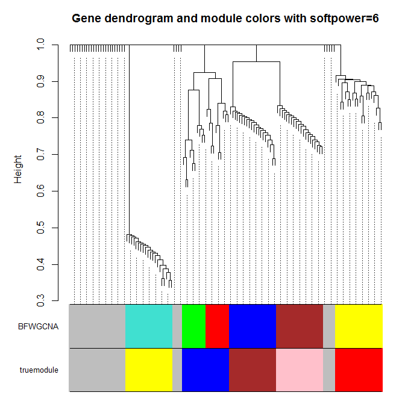

```r
obt<-BF_WGCNA(bfmatrix,pthres=0.05,plotTree=TRUE,plotfile="Gene_dendrogram_and_module_colors.pdf",minClusterSize=5,softPower=6,deepSplit=2);
#details in BFWGCNA Manual.
```

Figure 1: Gene dendrogram with true module colors for simulation data.

- Step4, output the resulting differential co-expression modules and some information of gene-gene interactions.

```r
bfoutput<-BF_output_networks(gene,class,obt,showMST2=TRUE,mst2file="mst2",bfthr=6,pthres=0.05,corthres=0.2);
#bfoutput is a list, it contains two elements: genegroups and network. Details in BFWGCNA Manual.

write.table(bfoutput$genegroups[bfoutput$genegroups$labels!=0,],file="gene_groups.txt",append=FALSE,row.names=FALSE,col.names=TRUE,quote=FALSE,sep="\t");
#output the resulting differential co-expression modules into gene_groups.txt (discard genes which are unassigned).
write.table(bfoutput$network,file="gene_network.txt",append=FALSE,row.names=FALSE,col.names=TRUE,quote=FALSE,sep="\t");
#output the resulting gene-gene interactions into gene_network.txt
```

### Estimate global gene importance by PageRank algorithm.

#### Test on simulation data

After running step1,

```r
load("bfmatrix.Rdata");
page<-BF_pagerank(bfmatrix,bfthr=6,pthres=0.05,d=0.85);
write.table(page,file="gene_ranks.txt",append=FALSE,row.names=FALSE,col.names=TRUE,quote=FALSE,sep="\t");
#output the resulting gene ranks into gene_ranks.txt
```

### Step-by-step BFWGCNA running on Monsanto data. Taking new gene expression data of tissue2 and trait43 as an example:

It will take about several to twenty minutes in total. It’s better to run it on a cluster.

- Step1, load data.

```r
library(BFWGCNA);
read.table("discrete_tissue2_Trait43nohead_data",header=FALSE,sep=" ")->data;
# file "discrete_tissue2_Trait43nohead_data" is a matrix containing class information and expression after preprocessing (gene selection and phenotype discretization). The first column correspond to class, other columns correspond to genes and rows to samples.
gene<-data[,2:dim(data)[2]];#Extract expression data
class<-data[,1];#Extract class
read.table("discrete_tissue2_Trait43head",header=FALSE,sep=" ")->genenames;
# file "discrete_tissue2_Trait43head" contains the colnames of data, separated by space.
names<-as.matrix(genenames[1,2:dim(genenames)[2]]);# extract the colnames from genenames.
colnames(gene)<-names[1,];#assign names to gene.
```

- Step2, caculate the pair-wise bayes factors from expression matrix and class.

```r
folder="./permutation100/";
Compute_bf(gene,class,permutation=TRUE,100,6)->bfmatrix;
save(bfmatrix,file=paste(folder,"bfmatrix_100_tissue2Trait43",sep=""));
write.table(bfmatrix,file=paste(folder,"bfmatrix_100_tissue2Trait43.txt",sep=""),append=FALSE,row.names=FALSE,col.names=TRUE,quote=FALSE);
```

- Step3, choose the soft-thresholding power by analysing of network topology

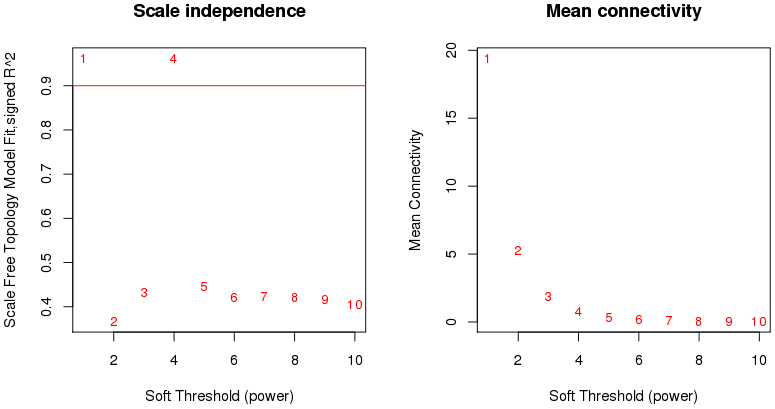

```r
load(paste(folder,"bfmatrix_100_tissue2Trait43",sep=""));
BF_Similarity(bfmatrix)->bfsimilarity;# Convert pair-wise bayes factors into network adjacency
powerlist=c(1:10);# candidate soft-thresholding powers
SelectPower(bfsimilarity,c(1:10));# plots a network topology under a set of candidate soft-thresholding powers
```

Figure 2: The left panel shows the scale-free fit index (y-axis) as a function of the soft-thresholding power (x-axis). The right panel shows the mean connectivity (degree, y-axis) as a function of the soft-thresholding power (x-axis). According to WGCNA, we choose softPower=1, which is the lowest power for which the scale-free topology fit index reaches 0.90. Details in BFWGCNA Manual.

- Step4, generate differential co-expression modules through pair-wise bayes factors.

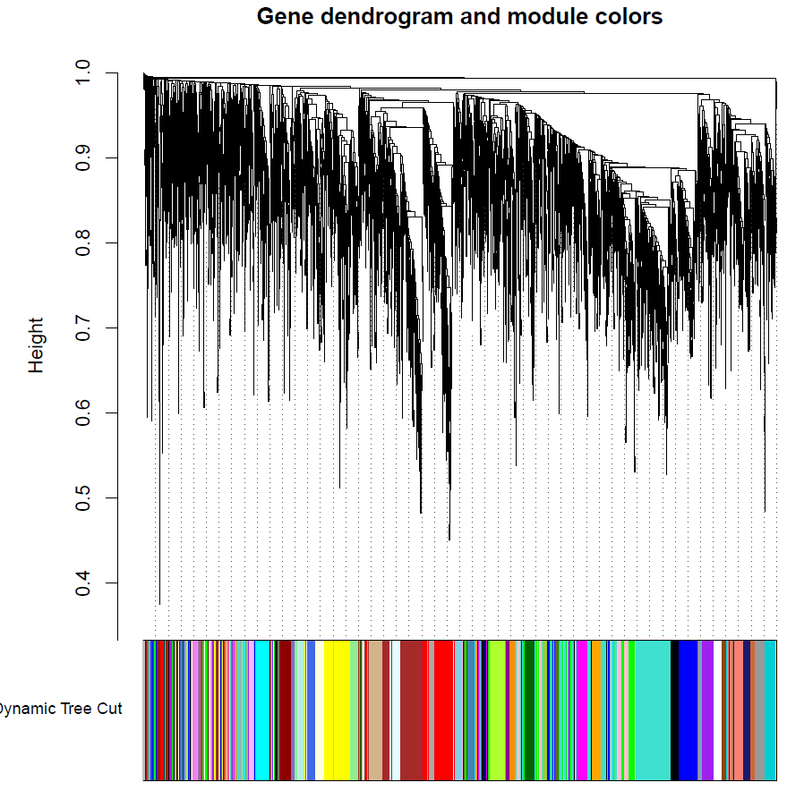

```r
BF_WGCNA(bfmatrix,plotTree=TRUE,plotfile=paste(folder,"Tree_tissue2_trait43",sep=""),softPower=1,deepSplit=1,minClusterSize=20)->obt;
save(obt,file=paste(folder,"obt_tissue2Trait43",sep=""));
```

Figure 3: Hierarchical clustering dendrogram and color annotations of modules in “Tree_tissue2_trait43”.

- Step5, output the resulting differential co-expression modules and some information of gene-gene interactions.

```r
load(paste(folder,"obt_tissue2Trait43",sep=""));
BF_output_networks(gene,class,obt,showMST2=TRUE,mst2file="mst2",bfthr=6,pthres=0.05,corthres=0.2)->output;

write.table(output$genegroups[output$genegroups$labels!=0,],file=paste(folder,"gene_groups_tissue2_trait43",sep=""),append=FALSE,row.names=FALSE,col.names=TRUE,quote=FALSE,sep="\t");
#output the resulting differential co-expression modules into gene_groups_tissue2_trait43.txt (discard genes which are unassigned).
write.table(output$network,file=paste(folder,"gene_network_100_tissue2_trait43",sep=""),append=FALSE,row.names=FALSE,col.names=TRUE,quote=FALSE,sep="\t");
#output the resulting gene-gene interactions into gene_network_100_tissue2_trait43.txt
```

### Estimate global gene importance by PageRank algorithm.

#### For new gene expression data of tissue2 and trait43.

After running step1,

```r
folder="./permutation100/";
load(paste(folder,"bfmatrix_100_tissue2Trait43",sep=""));
page<-BF_pagerank(bfmatrix,bfthr=6,pthres=0.01,d=0.85);
write.table(page,file="pagerank_tissue2_trait43.txt",append=FALSE,row.names=FALSE,col.names=TRUE,quote=FALSE,sep="\t");
#output the resulting gene ranks into pagerank_tissue2_trait43.txt
```